# assignment 6

Oyedayo Oyelowo

2 November 2017

```r
#puudata.xls is used in every exercise
#clear memory
rm(list = ls())
setwd("C:/Users/oyeda/Desktop/R_COURSE/assignment6")
#load the data
data<-read.table("puudata.txt", header = T, sep = "\t")
```

### Exercise 1

- Construct a linear height model for spruces (PUULAJI = 2) in the - first canopy cover layer. Use
- diameter (LPM) as an explanatory variable. Report the model’s - - parameters, coefficient of
- determination, and residual error. Report also the p-value of the - explanatory variable.

```r
spruceCanopy1 <- subset(data, data$PUULAJI==2 & data$LATVKERROS==1)
lm_fit = lm(formula= PITUUS~LPM, data=spruceCanopy1)
summary(lm_fit)
```

```
##
## Call:
## lm(formula = PITUUS ~ LPM, data = spruceCanopy1)
##
## Residuals:
##      Min       1Q   Median       3Q      Max
## -298.656  -16.420   -1.221   17.060  114.284
##
## Coefficients:
##              Estimate Std. Error t value Pr(>|t|)
## (Intercept) 31.726999   1.414875   22.42   <2e-16 ***
## LPM          0.676181   0.006779   99.75   <2e-16 ***
## ---
## Signif. codes:  0 '***' 0.001 '**' 0.01 '*' 0.05 '.' 0.1 ' ' 1
##
## Residual standard error: 27.77 on 1709 degrees of freedom
## Multiple R-squared:  0.8534, Adjusted R-squared:  0.8533
## F-statistic:  9950 on 1 and 1709 DF,  p-value: < 2.2e-16
```

```r
names(lm_fit)
```

```
##  [1] "coefficients"  "residuals"     "effects"       "rank"
##  [5] "fitted.values" "assign"        "qr"            "df.residual"
##  [9] "xlevels"       "call"          "terms"         "model"
```

- Parameters: “LPM” and “intercept”
- coefficient of determination: 0.8534
- p-value: < 2.2e-16

## Exercise 2

### Exercise 1 continues.

- **Plot the model’s residual error as a function of diameter.**
- **Does the variance change as diameter grows?**

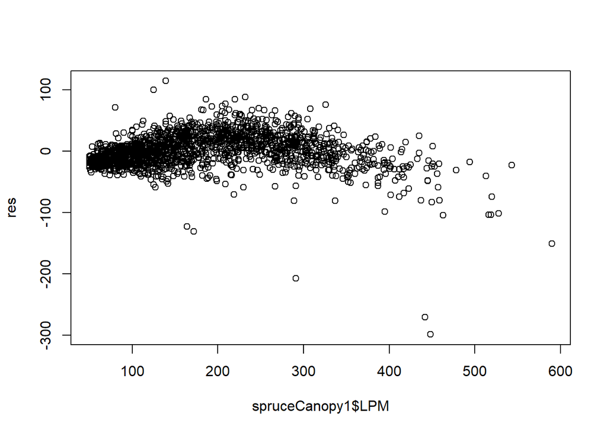

```r
res =residuals(lm_fit)
plot(res~ spruceCanopy1$LPM)
```

- **The variance changes slightly as the diameter grows. There are a few larger residuals as the diameter grows**

```r
#{oldpar <- par(mfrow = c(2, 2))
#plot(lm_fit)
#par(oldpar)}
```

## Exercise 3

### Exercise 1 continues.

- **Plot the height of spruces in the first canopy layer as a function of diameter. Add a red curve to the picture that illustrates the values predicted with the model.**

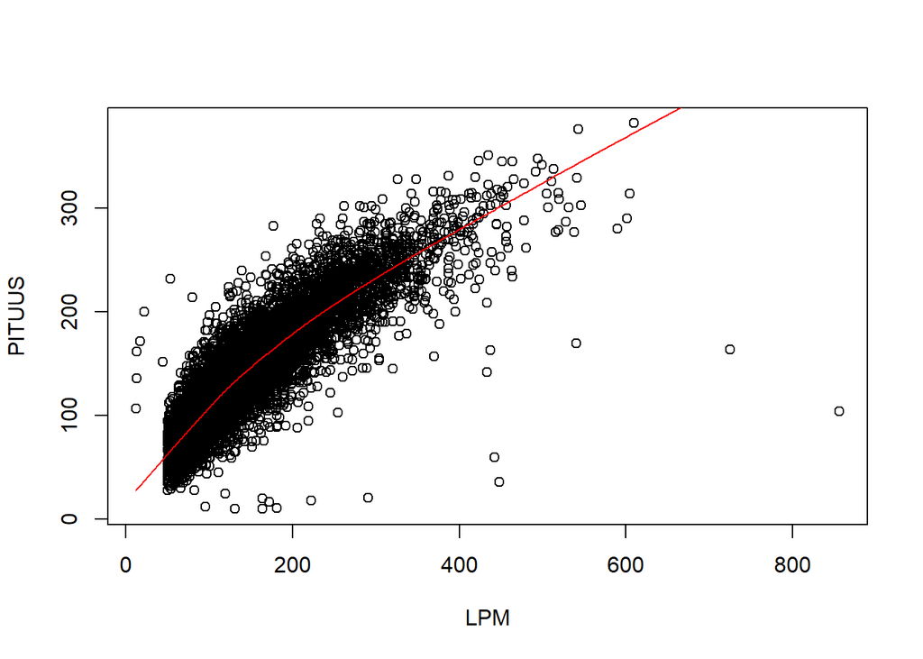

```r
spr1<- data[data["LATVKERROS"]==1,]
plot(PITUUS~LPM, spr1)
lines(lowess(spr1$LPM, spr1$PITUUS), col="red")
```

```r
#abline(lm_fit, col="purple")
#or
#abline(coef = coef(lm_fit), col="red")
```

## Exercise 4

### Exercise 1 continues.

- Develop the model further. Add new explanatory variables from the puudata and examine how model’s coefficient of determination and residual error #change. Can you make the model better and if so, which explanatory variables belong into the model?

```r
lm_fit2= lm(formula= PITUUS~LPM+ELAVALARAJA, data=spruceCanopy1)
lm_fit3= lm(formula= PITUUS~LPM+ELAVALARAJA+LATVUSLEV, data=spruceCanopy1)
summary(lm_fit2)
```

```
##
## Call:
## lm(formula = PITUUS ~ LPM + ELAVALARAJA, data = spruceCanopy1)
##
## Residuals:
##     Min      1Q  Median      3Q     Max
## -291.78  -12.94   -0.94   14.08  116.64
##
## Coefficients:
##              Estimate Std. Error t value Pr(>|t|)
## (Intercept) 30.018163   1.278822   23.47   <2e-16 ***
## LPM          0.595353   0.007347   81.04   <2e-16 ***
## ELAVALARAJA  0.365241   0.018412   19.84   <2e-16 ***
## ---
## Signif. codes:  0 '***' 0.001 '**' 0.01 '*' 0.05 '.' 0.1 ' ' 1
##
## Residual standard error: 25.04 on 1708 degrees of freedom
## Multiple R-squared:  0.8809, Adjusted R-squared:  0.8807
## F-statistic:  6314 on 2 and 1708 DF,  p-value: < 2.2e-16
```

```r
summary(lm_fit3)
```

```
##
## Call:
## lm(formula = PITUUS ~ LPM + ELAVALARAJA + LATVUSLEV, data = spruceCanopy1)
##
## Residuals:
##      Min       1Q   Median       3Q      Max
## -295.252  -12.822   -0.758   13.863  116.796
##
## Coefficients:
##              Estimate Std. Error t value Pr(>|t|)
## (Intercept) 31.257848   1.303859  23.973  < 2e-16 ***
## LPM          0.620567   0.009336  66.471  < 2e-16 ***
## ELAVALARAJA  0.366603   0.018319  20.012  < 2e-16 ***
## LATVUSLEV   -0.353131   0.081355  -4.341  1.5e-05 ***
## ---
## Signif. codes:  0 '***' 0.001 '**' 0.01 '*' 0.05 '.' 0.1 ' ' 1
##
## Residual standard error: 24.91 on 1707 degrees of freedom
## Multiple R-squared:  0.8822, Adjusted R-squared:  0.882
## F-statistic:  4260 on 3 and 1707 DF,  p-value: < 2.2e-16
```

```r
summary(lm_fit)
```

```
##
## Call:
## lm(formula = PITUUS ~ LPM, data = spruceCanopy1)
##
## Residuals:
##      Min       1Q   Median       3Q      Max
## -298.656  -16.420   -1.221   17.060  114.284
##
## Coefficients:
##              Estimate Std. Error t value Pr(>|t|)
## (Intercept) 31.726999   1.414875   22.42   <2e-16 ***
## LPM          0.676181   0.006779   99.75   <2e-16 ***
## ---
## Signif. codes:  0 '***' 0.001 '**' 0.01 '*' 0.05 '.' 0.1 ' ' 1
##
## Residual standard error: 27.77 on 1709 degrees of freedom
## Multiple R-squared:  0.8534, Adjusted R-squared:  0.8533
## F-statistic:  9950 on 1 and 1709 DF,  p-value: < 2.2e-16
```

**ELAVALARAJA(lower limit of living canopy ) was added the coefficient of determination increased from 0.8534 to 0.8809 and the residual standard error reduced from 27.77 to 25. 04**